# Fecundity reduction due to oil in bottlenose dolphins in Barataria Bay

# Preamble

This is an Electronic Supplement to the manuscript Schwacke et al. 2022. Modeling population effects of the Deepwater Horizon oil spill on a long-lived species. $Conservation~Biology$ 36:e13878 DOI: https://doi.org/10.1111/cobi.13878

The master file containing links to all supplementary files related to this paper is BND_Electronic Supplements master file.

If you make use of any of this material in your work, it would be appreciated if you would contact Tiago Marques to let him know.

# Introduction

This document briefly describes the assumed fecundity reduction factor induced by oil exposure. This reduction is the quotient of two independent random variables with a Beta distribution, describing reproductive success probabilities before and after oil exposure.

The raw data we have for parametrizing the reduction in fecundity is the number of trials and successes for females, before and after the oil. See main paper for details and data sources.

```r
#no oil spill trials - baseline
n4brs<-34
#no oil spill successes - baseline
suc4brs<-22
#oil spill trials - impact
n4pors<-36
#oil spill successes - impact
suc4pors<-7
```

From these values one can generate random deviates with a mean and variance consistent with the observed proportion of successes.

This would be achieved by generating a binomial random variable with the number of trials and successes observed, and dividing it by the number of trials. However, the resulting quantity is not a binomial random variable, and it is a discrete approximation for a quantity that we know is continuous, given it is a probability, in the population.

Hence we opted by approximating that probability by a beta random variable with the empirical mean and variance induced by the number of trials and number of successes observed, in the absence and in the presence of oil.

## Abcense of oil

The original number of trials and successes in the absence of oil was 34 and 22, corresponding to a probability of success of 0.647. We can check what is the corresponding mean and precision that we get when we generate draws from such a binomial divided by the observed number of trials

```r
#empirical mean and variance of the proportion
B<-1000000
#mean
psuc<-rbinom(B,size=n4brs,prob = suc4brs/n4brs)/n4brs
mpsuc<-mean(psuc)
#variance
vpsuc<-var(psuc)
#standard deviation
spsuc<-sd(psuc)
```

```r
p<-0.6471866
sd.p<-0.08194595
```

We can compute the values for the parameters of the corresponding Beta that shares the same mean and standard deviation

```r
# transform to corresponding beta parameters
alpha <- ((1 - p) / sd.p^2 - 1 / p) * p ^ 2
beta <- alpha * (1 / p - 1)
# get Baseline reproductive success rate
pRepbasesims <- rbeta(B, alpha, beta)
#check empirical mean and variance
```

which naturally, by construction, will have the desired original mean and variance

```r
mean(pRepbasesims)
```

```
## [1] 0.6472
```

```r
var(pRepbasesims)
```

```
## [1] 0.006722
```

We can take a look at the realizations of the simulated values from this distribution

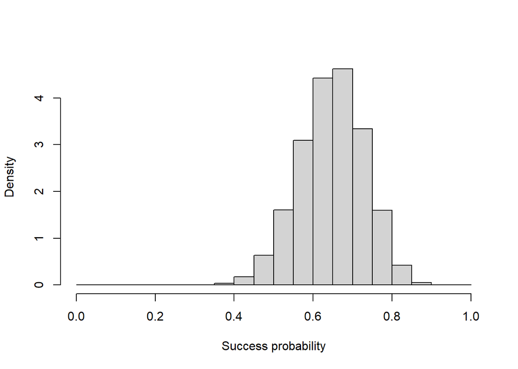

```r
#look at the histogram of random deviates
hist(pRepbasesims,breaks=seq(0,1,by=0.05),main="",xlab="Success probability",freq=FALSE)
```

## Presence of oil

The original number of trials and successes was 36 and 7, corresponding to a probability of success of 0.194. As above, the empirical mean and precision measures for the proportion that we get from simulating probabilities from these are

```r
#empirical mean and variance of the proportion
B<-1000000
#mean
psuco<-rbinom(B,size=n4pors,prob = suc4pors/n4pors)/n4pors
mpsuco<-mean(psuco)
#variance
vpsuco<-var(psuco)
#standard deviation
spsuco<-sd(psuco)
```

a mean of 0.1945, a variance of 0.0044 and a standard deviation of 0.066.

The values in file `SpeciesDefinitionFile.xlsx` for `meanpors` and `sdpors` are

```r
p<-0.1944686
sd.p<-0.06596507
```

These are the values for the parameters of the corresponding Beta

```r
# transform to corresponding beta parameters
alpha <- ((1 - p) / sd.p^2 - 1 / p) * p ^ 2
beta <- alpha * (1 / p - 1)
# get Baseline reproductive success rate
pRepbasesims <- rbeta(B, alpha, beta)
#check empirical mean and variance
```

We can compute the mean and variance from the corresponding Beta

```r
mean(pRepbasesims)
```

```
## [1] 0.1944
```

```r
var(pRepbasesims)
```

```
## [1] 0.004357
```

We can take a look at the realizations of the simulated values.

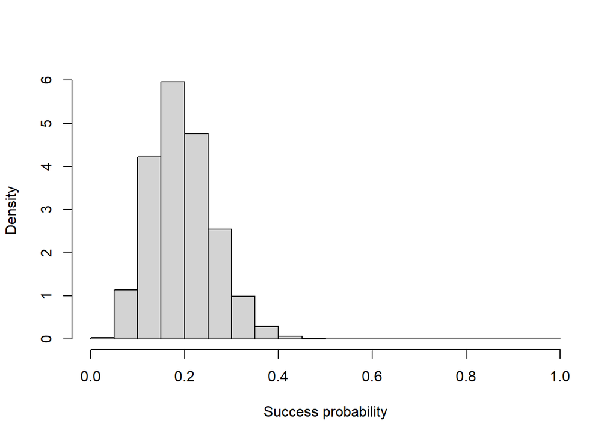

```r
#look at the histogram of random deviates
hist(pRepbasesims,breaks=seq(0,1,by=0.05),main="",xlab="Success probability",freq=FALSE)
```

# The fecundity reduction factor

The fecundity pre- and post-spill are represented below

```r
source("Functions/reqfuns.R") # most functions are here
SpInfo <- getSpData("Ttru")
```

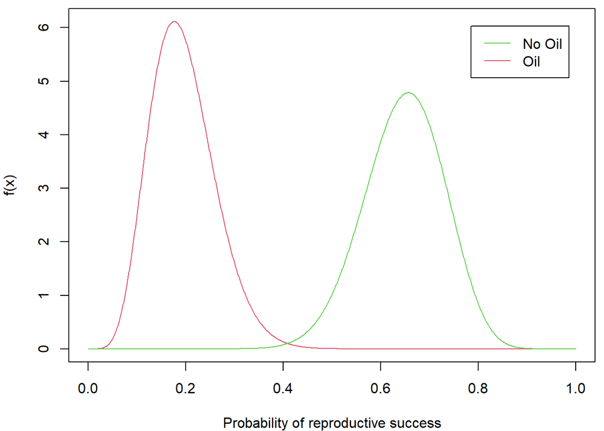

```r
par(mfrow=c(1,1),mar=c(4,4,0.5,0.5))
xs<-seq(0,1,by=0.001)
 # get parameters of binomial
beta.pars.pre <- getBetaDistPars(SpInfo$meanbrs, SpInfo$sdbrs^2)
# get Baseline reproductive success rate
preoil <- dbeta(xs, beta.pars.pre$alpha, beta.pars.pre$beta)
 # get parameters of binomial
beta.pars.pos <- getBetaDistPars(SpInfo$meanpors, SpInfo$sdpors^2)
# get post spill reproductive success rate
postoil <- dbeta(xs, beta.pars.pos$alpha, beta.pars.pos$beta)
plot(xs,postoil,col=2,ylab="f(x)",xlab="Probability of reproductive success",type="l")
lines(xs,preoil,col=3)
legend("topright",col=3:2,lty=1,legend=c("No Oil","Oil"),inset=0.05)
```

and the corresponding fecundity reduction factor density plot is

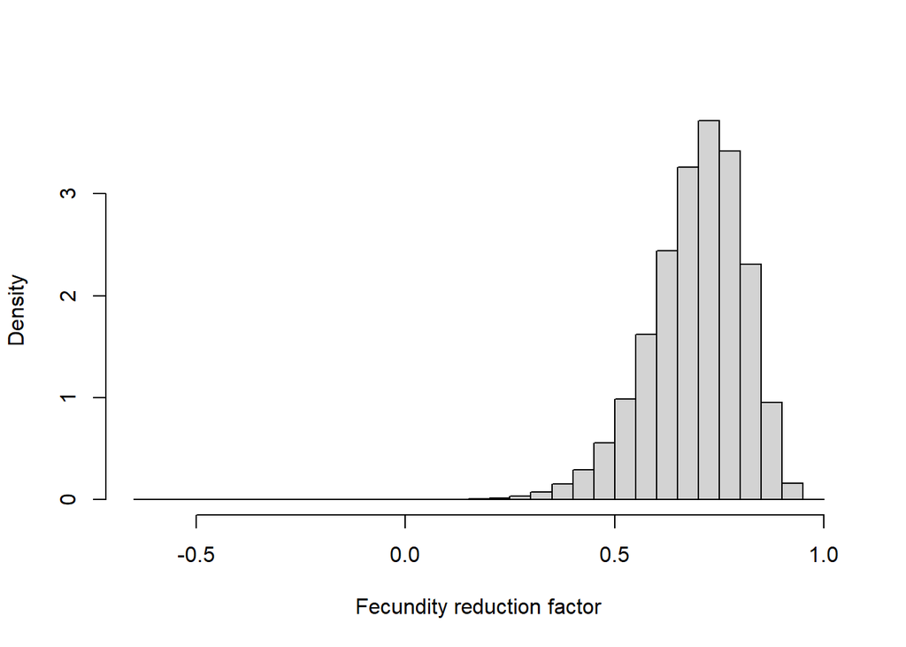

```r
#note strictly we are approximating empirically the distribution of the reduction factor
set.seed(123)
n<-10000000
fecRed<-1-rbeta(n, beta.pars.pos$alpha, beta.pars.pos$beta)/rbeta(n, beta.pars.pre$alpha, beta.pars.pre$beta)
hist(fecRed,freq=FALSE,main="",xlab="Fecundity reduction factor")
```

which leads to a mean reduction factor of 0.694 (95% CI 0.438,0.875).